# Lesson 7 Part A, B Quizzs

Chun Hsien Wu

2021年6月8日

### Anscombe data set bayesian analysis using JAGS

#### Lesson 7 part A Question 3

Consider the Anscombe data set in R Suppose we are interested in relating per-capita education expenditures to the other three variables. Which variable appears to have the strongest linear relationship with per-capita education expenditures?

```r
library("car")  # load the 'car' package
data("Anscombe")  # load the data set
?Anscombe  # read a description of the data
head(Anscombe)  # look at the first few lines of the data
```

```
##    education income young urban
## ME       189   2824 350.7   508
## NH       169   3259 345.9   564
## VT       230   3072 348.5   322
## MA       168   3835 335.3   846
## RI       180   3549 327.1   871
## CT       193   4256 341.0   774
```

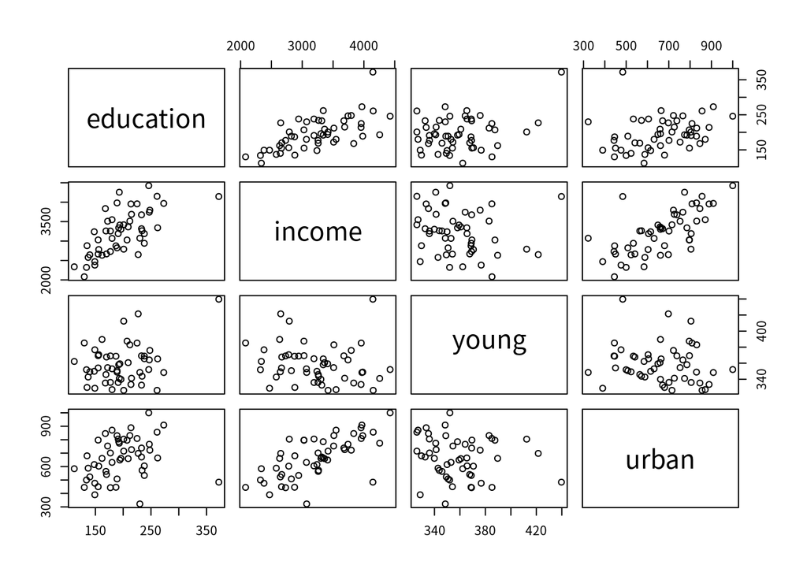

```r
pairs(Anscombe)  # scatter plots for each pair of variables
```

```r
lmod = lm(education ~ income + young + urban, data=Anscombe)
summary(lmod)
```

```
##
## Call:
## lm(formula = education ~ income + young + urban, data = Anscombe)
##
## Residuals:
##     Min      1Q  Median      3Q     Max
## -60.240 -15.738  -1.156  15.883  51.380
##
## Coefficients:
##               Estimate Std. Error t value Pr(>|t|)
## (Intercept) -2.868e+02  6.492e+01  -4.418 5.82e-05 ***
## income       8.065e-02  9.299e-03   8.674 2.56e-11 ***
## young        8.173e-01  1.598e-01   5.115 5.69e-06 ***
## urban       -1.058e-01  3.428e-02  -3.086  0.00339 **
## ---
## Signif. codes:  0 '***' 0.001 '**' 0.01 '*' 0.05 '.' 0.1 ' ' 1
##
## Residual standard error: 26.69 on 47 degrees of freedom
## Multiple R-squared:  0.6896, Adjusted R-squared:  0.6698
## F-statistic: 34.81 on 3 and 47 DF,  p-value: 5.337e-12
```

#### Question 4

Fit a reference (noninformative) Bayesian linear model to the Anscombe data with education expenditures as the response variable and include all three other variables as predictors. Use the lm function in R.

What is the posterior mean estimate of the intercept in this model? Round your answer to one decimal place.

#### Question 5

In our reference analysis of the Anscombe data, the intercept is estimated to be negative. Does this parameter have a meaningful interpretation?

The answer is **No, it represents expected expenditures in a state with 0 average income, 0 percent youth, and 0 percent urban which doesn’t exist.**

### LESSON 7 PART B

#### question 3

Although the residual analysis of the Anscombe data showed no major problem that we will pursue, it is still worthwhile to compare some competing models. First, calculate and report the DIC for the original model (that you fit for the previous quiz). Round your answer to the nearest whole number. Now, using JAGS

```r
library("rjags")
mod1_string = " model {
    for (i in 1:length(education)) {
        education[i] ~ dnorm(mu[i], prec)
        mu[i] = b0 + b[1]*income[i] + b[2]*young[i] + b[3]*urban[i]
    }

    b0 ~ dnorm(0.0, 1.0/1.0e6)
    for (i in 1:3) {
        b[i] ~ dnorm(0.0, 1.0/1.0e6)
    }

    prec ~ dgamma(1.0/2.0, 1.0*1500.0/2.0)
        ## Initial guess of variance based on overall
        ## variance of education variable. Uses low prior
        ## effective sample size. Technically, this is not
        ## a true 'prior', but it is not very informative.
    sig2 = 1.0 / prec
    sig = sqrt(sig2)
} "


data(Anscombe)
data_jags = as.list(Anscombe)

params1 = c("b", "sig")

inits1 = function() {
    inits = list("b"=rnorm(3,0.0,100.0), "prec"=rgamma(1,1.0,1.0))
}

mod1 = jags.model(textConnection(mod1_string), data=data_jags, inits=inits1, n.chains=3)
update(mod1, 10000) # burn-in

mod1_sim = coda.samples(model=mod1,
                        variable.names=params1,
                        n.iter=5000)

mod1_csim = do.call(rbind, mod1_sim) # combine multiple chains
```

Before checking inferences from the model, we should perform convergence diagnostics for our markov chains.

```r
gelman.diag(mod1_sim)
```

```
## Potential scale reduction factors:
##
##      Point est. Upper C.I.
## b[1]       1.02       1.07
## b[2]       1.14       1.41
## b[3]       1.02       1.05
## sig        1.00       1.00
##
## Multivariate psrf
##
## 1.08
```

```r
autocorr.diag(mod1_sim)
```

```
##             b[1]      b[2]      b[3]        sig
## Lag 0  1.0000000 1.0000000 1.0000000 1.00000000
## Lag 1  0.9834997 0.9941276 0.9676685 0.06311365
## Lag 5  0.9219599 0.9726134 0.8559402 0.05386551
## Lag 10 0.8520070 0.9488023 0.7391930 0.02088067
## Lag 50 0.4960127 0.7989038 0.2814864 0.01216750
```

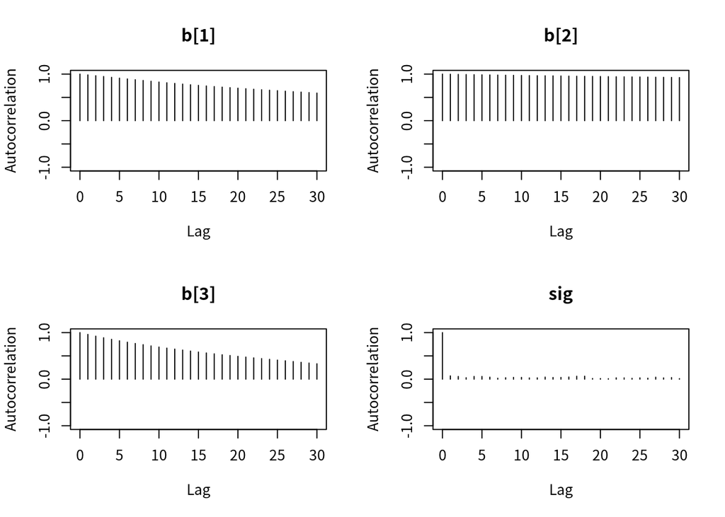

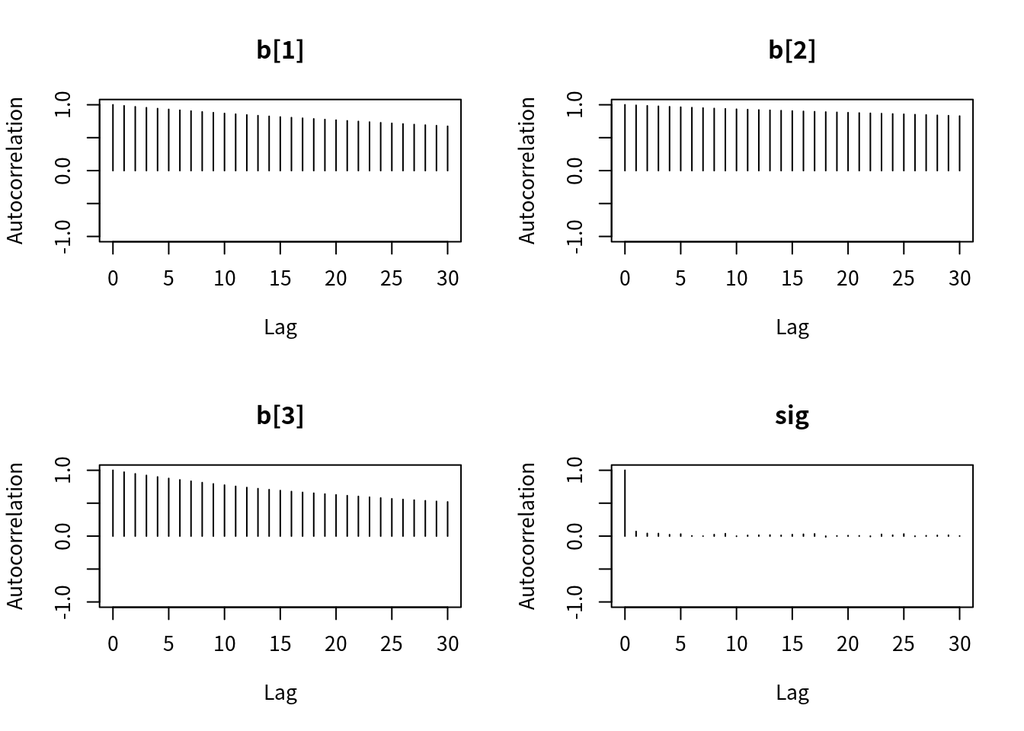

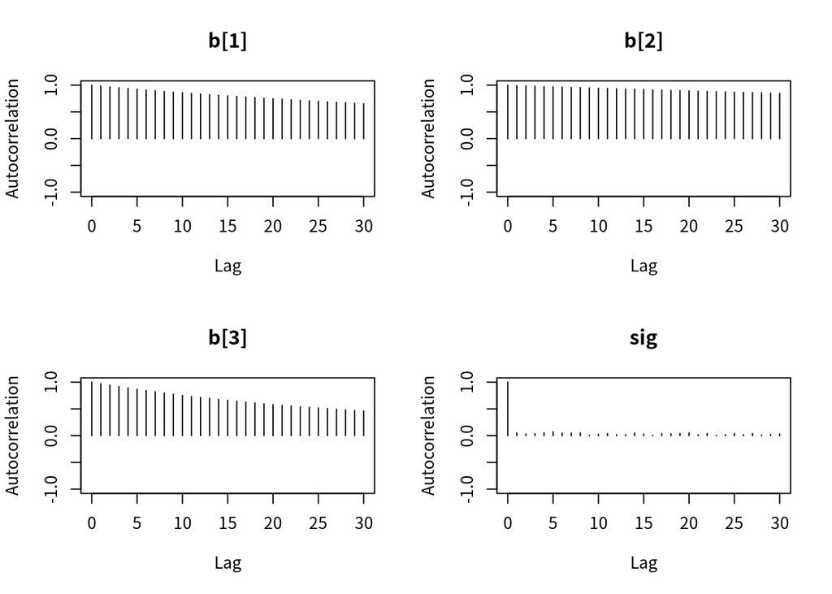

```r
autocorr.plot(mod1_sim)
```

```r
effectiveSize(mod1_sim)
```

```
##       b[1]       b[2]       b[3]        sig
##  122.22300   41.99645  237.00868 6347.78442
```

```r
dic.samples(mod1, 1e5)
```

```
## Mean deviance:  480.9
## penalty 5.244
## Penalized deviance: 486.2
```

We can get a posterior summary of the parameters in model 1. This is our preferred because of the lowest DIC value.

```r
summary(mod1_sim)
```

```
##
## Iterations = 10001:15000
## Thinning interval = 1
## Number of chains = 3
## Sample size per chain = 5000
##
## 1. Empirical mean and standard deviation for each variable,
##    plus standard error of the mean:
##
##          Mean       SD  Naive SE Time-series SE
## b[1]  0.08173 0.009304 7.597e-05      0.0008368
## b[2]  0.81290 0.162445 1.326e-03      0.0277041
## b[3] -0.11070 0.032158 2.626e-04      0.0021286
## sig  27.40172 2.862633 2.337e-02      0.0378210
##
## 2. Quantiles for each variable:
##
##         2.5%      25%      50%      75%    97.5%
## b[1]  0.0638  0.07516  0.08186  0.08842  0.09947
## b[2]  0.4576  0.72167  0.82957  0.92598  1.08774
## b[3] -0.1736 -0.13279 -0.11043 -0.08910 -0.04774
## sig  22.4998 25.39155 27.14256 29.13460 33.60043
```

##### Alternative model 2

We will consider two alternative models for the Anscombe data. Because income and urban may be more highly correlated with each other than with education, and since urban was less significant than income in our models so far, we’ll consider dropping it.

Belows are model2 jags codes:

```r
mod2_string = " model {
    for (i in 1:length(education)) {
        education[i] ~ dnorm(mu[i], prec)
        mu[i] = b0 + b[1]*income[i] + b[2]*young[i]
    }

    b0 ~ dnorm(0.0, 1.0/1.0e6)
    for (i in 1:2) {
        b[i] ~ dnorm(0.0, 1.0/1.0e6)
    }

    prec ~ dgamma(1.0/2.0, 1.0*1500.0/2.0)

    sig2 = 1.0 / prec
    sig = sqrt(sig2)
} "

set.seed(72)

# drop urban from Anscombe
dat2 = subset(Anscombe, select = c("education", "income", "young"))
# or you can do like this, it's much tidier
# dat2_jags = as.list(Anscombe[,-4])

dat2_jags = as.list(dat2)

params2 = c("b", "sig")

inits1 = function() {
    inits = list("b"=rnorm(2,0.0,100.0), "prec"=rgamma(1,1.0,1.0))
}

mod2 = jags.model(textConnection(mod2_string), data=dat2_jags, inits=inits1, n.chains=3)
update(mod2, 1000) # burn-in

mod2_sim = coda.samples(model=mod2,
                        variable.names=params2,
                        n.iter=5000)

mod2_csim = do.call(rbind, mod2_sim) # combine multiple chains

# checking convergence
gelman.diag(mod2_sim)
```

```
## Potential scale reduction factors:
##
##      Point est. Upper C.I.
## b[1]       1.05       1.16
## b[2]       1.07       1.21
## sig        1.00       1.01
##
## Multivariate psrf
##
## 1.07
```

```r
autocorr.diag(mod2_sim)
```

```
##             b[1]      b[2]        sig
## Lag 0  1.0000000 1.0000000 1.00000000
## Lag 1  0.9670105 0.9939695 0.07359154
## Lag 5  0.8441297 0.9697488 0.03830564
## Lag 10 0.7122314 0.9408010 0.02183145
## Lag 50 0.2189273 0.7371995 0.02239205
```

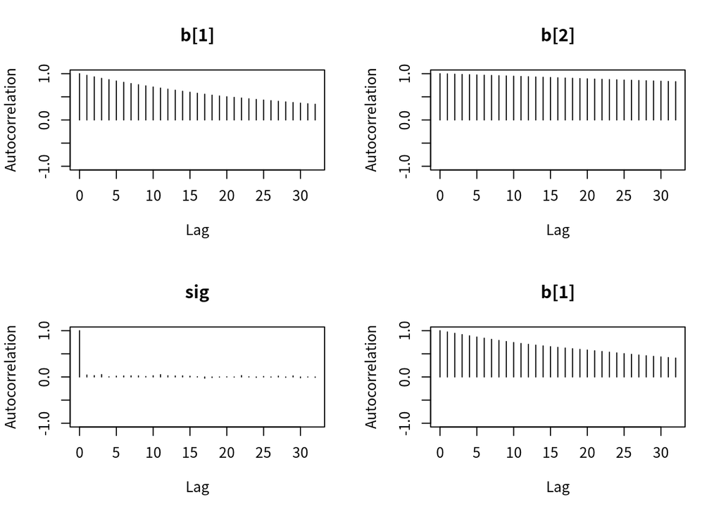

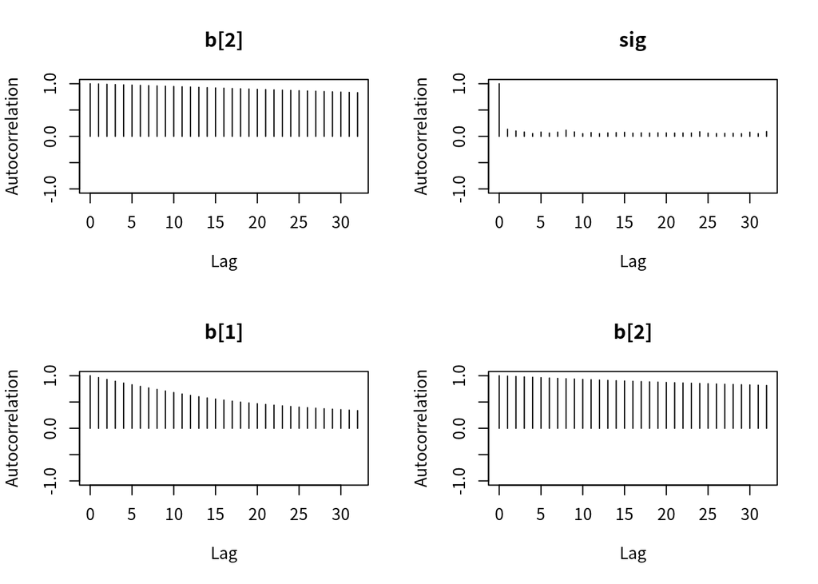

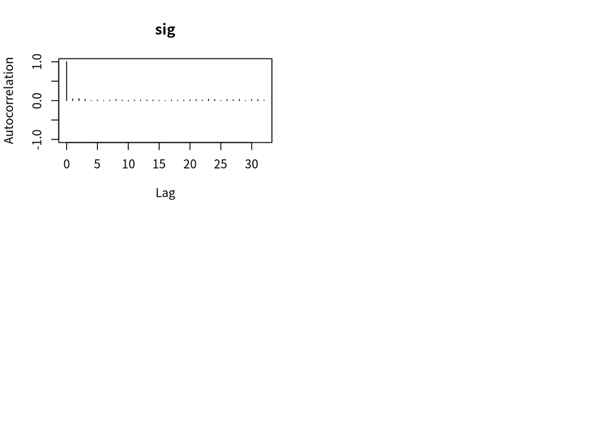

```r
autocorr.plot(mod2_sim)
```

```r
# calculating DIC
dic.samples(mod2,1.0e5)
```

```
## Mean deviance:  489.2
## penalty 4.201
## Penalized deviance: 493.4
```

##### Alternative model 3

Question 4 In addition to dropping urban, add an interaction terms b3 * income[i] * youth[i] and fit model in JAGS.

Calculating the DIC, if predictive performance is our criterion, which model would you conclude performs best ?

```r
mod3_string = " model {
    for (i in 1:length(education)) {
        education[i] ~ dnorm(mu[i], prec)
        mu[i] = b0 + b[1]*income[i] + b[2]*young[i] + b[3] * income[i] * young[i]
    }

    b0 ~ dnorm(0.0, 1.0/1.0e6)
    for (i in 1:3) {
        b[i] ~ dnorm(0.0, 1.0/1.0e6)
    }

    prec ~ dgamma(1.0/2.0, 1.0*1500.0/2.0)

    sig2 = 1.0 / prec
    sig = sqrt(sig2)
} "

set.seed(72)

# drop urban from Anscombe
dat3 = subset(Anscombe, select = c("education", "income", "young"))

dat3_jags = as.list(dat3)

params3 = c("b", "sig")

inits1 = function() {
    inits = list("b"=rnorm(3, 0.0, 100.0), "prec"=rgamma(1,1.0,1.0))
}

mod3 = jags.model(textConnection(mod3_string), data=dat3_jags, inits=inits1, n.chains=3)
update(mod3, 1000) # burn-in
```

```r
mod3_sim = coda.samples(model=mod3,
                        variable.names=params3,
                        n.iter=5000)
mod3_csim = do.call(rbind, mod3_sim)
```

```r
# checking convergence
gelman.diag(mod3_sim)
```

```
## Potential scale reduction factors:
##
##      Point est. Upper C.I.
## b[1]       6.31       15.6
## b[2]       5.89       14.4
## b[3]       6.41       15.5
## sig        1.80        3.0
##
## Multivariate psrf
##
## 4.9
```

```r
autocorr.diag(mod3_sim)
```

```
##             b[1]      b[2]      b[3]       sig
## Lag 0  1.0000000 1.0000000 1.0000000 1.0000000
## Lag 1  0.9972491 0.9981969 0.9968819 0.8853806
## Lag 5  0.9862105 0.9910464 0.9848559 0.8642052
## Lag 10 0.9728511 0.9828093 0.9703005 0.8385793
## Lag 50 0.8680119 0.9340299 0.8634138 0.6720674
```

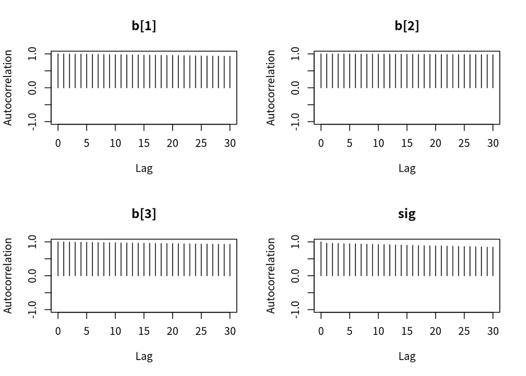

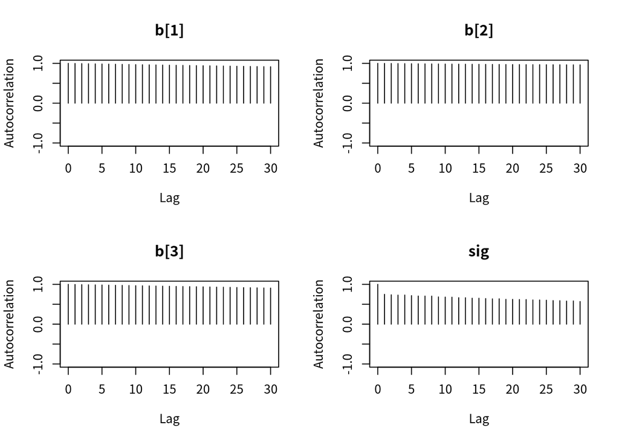

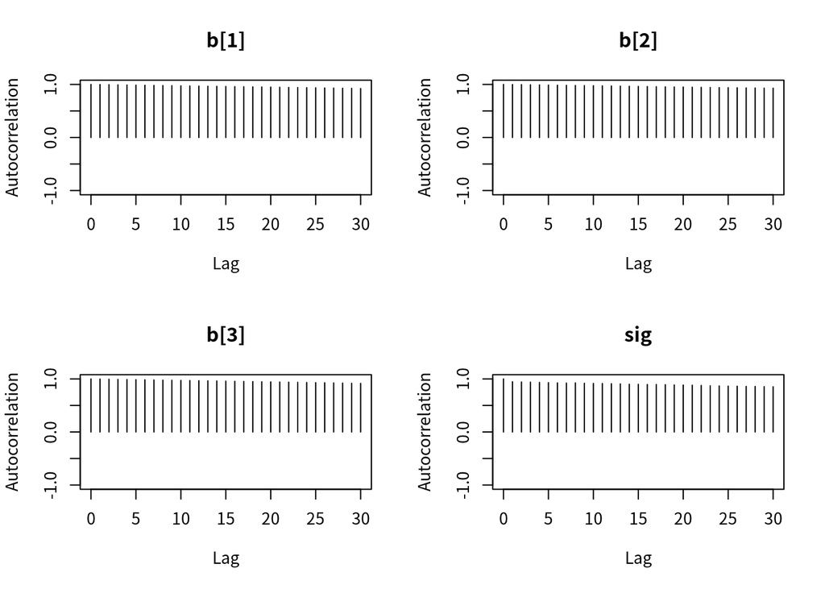

```r
autocorr.plot(mod3_sim)
```

```r
# calculating DIC
dic.samples(mod3,1.0e5)
```

```
## Mean deviance:  487.8
## penalty 5.299
## Penalized deviance: 493.1
```

#### Question 5

Using the model favored by the DIC, obtain a Monte Carlo estimate of the posterior probability that the coefficient for income is positive(greater than 0.0). Round your answer to two decimal places.

```r
print(mean(mod1_csim[,1]>0))
```

```
## [1] 1
```